# GAM power analysis

Chris Terry

# Introduction

This document conducts a basic power analysis through simulation of the capacity for GAMs to identify higher-order interactions in response surface of plausible *Drosophila* experimental data.

The core objective is to estimate the finite rate of population increase, **$\lambda$**, given the focal population density $N_{i,t}$, the competitor density $N_{j,t}$ and the temperature $T_t$.

$$N_{i,t+1}=N_{i,t}\lambda_{i,t}$$
$$\lambda_{i,t}=f_i(N_{i,t}, N_{j,t}, T_t)$$
The core result is that that several thousand observations are likely to be sufficient to be able to detect 3-way interactions that cause +/- 20% impact, given plausible levels of experimental noise.

# Generating simulated data.

## Model

Data generating models are derived from the results of Terry (2025, https://doi.org/10.1111/ele.70047), in which extensive model selection was used to fit models of thermal performance and competition for two fly species *Drosophila pandora* and *Drosophila pallidifrons*. The generations are discrete - adults are able to lay eggs for a fixed period then removed. After 10 days development, the subsequent emergent adults are then counted.

The best fit model used described the error with a zero-inflated negative binomial model.

In that experiment Drosophila vials were used, whereas in this trial I will instead use larger Drosophila bottles, that will be able to support a larger population, however for the purposes of power analysis the underlying dynamics is likely to be similar.

The best model (selected via ELPD-LOO) for the expected values was:

$$\lambda
=\underbrace{B_0T(T-T_{\min})\sqrt{T_{\max}-T}}_{\text{thermal
performance}}
\times
\underbrace{\frac{1}{1+\alpha_{ii}N_i+\alpha_{ij}(T)N_j}}_{\text{Beverton-Holt
Competition}}$$

where the competition was linearly dependent on the temperature (scaled to aid fitting)

$$\alpha_{ij}(T)=\alpha_{ij0}+\alpha_{ijT}(T-20).$$

and draws are from a zero-inflated negative-binomial model.

```r
library(tidyverse)
library(mgcv)
library(gratia) # for visualising GAMs
```

## Parameters

Parameters for one of the species, *D. pandora*, are taken from the posterior mean values from the archived model fits (https://github.com/jcdterry/MCT_Fly_Val_public/blob/main/Analysis/4_Inferences-from-best-fit-models.html) .

```r
# Parameters from the PAN best-fit model
B0        <- 0.01
Tmin      <- 17.82
Tmax      <- 33.59

alphaii   <- 0.17
alphaij0  <- 0.74
alphaijT  <- -0.06

# Negative-binomial / zero-inflation parameters
shape_intercept <- -1.14
shape_focal     <- 0.05
zi              <- 0.04
```

## Potential Experimental Design

The choice of levels will be adaptive, with later blocks emphasising areas of greater change to maximise the information from the sampling. To represent that in this analysis, the sampling at lower levels is increased.

```r
# Experimental design
density_values<- c(0,0,  # extra replication at zero
                   seq(0, 20, by= 4), # dense low-density coverage
                   seq(30, 100, by =10)) # # broader high-density coverage

dat <- expand_grid(temp = seq(22, 28, length.out = 7),
                      focal_density = density_values,
                      comp_density =density_values,
                      replicate = 1:6)
```

## Underlying biological response surface

```r
# temp-dependent intrinsic growth
therm_perf <-
  B0 * dat$temp * (dat$temp - Tmin) * sqrt(pmax(Tmax - dat$temp, 0))

# temp-dependent interspecific competition
alphaij <-alphaij0 + alphaijT * (dat$temp - 20)

## Expected value at next generation
mu <-dat$focal_density *therm_perf/( 1+alphaii*dat$focal_density+alphaij*dat$comp_density)
```

## Adding noise to the observations

Three points complicate generating an appropriate amount of noise on top of the expected values:

- In the planned experiments, I will use Drosophila bottles, rather than vials, which are somewhat larger. Increasing the size of the container will somewhat reduce the demographic noise as the carrying capacity can be mostly controlled by the amount of food available. Based on previous work, populations may be approximately 4x larger than in the vials. I have accounted for this by scaling the size parameter with this.
- In the 2025 paper, the best fit model identified that dispersion scaled with the population density. This is included by linking the shape parameter to the focal density.
- A feature of Drosophila assays in the vials is the sizeable fraction of zero’s, where the line collapses (this can be due to too high a density, delaying development, or something causing no eggs to be laid). In bottles this is likely to be less pronounced than in vials, but here maintaining the zero-inflation observed in the experiment (4%) as a conservative test.

```r
shape_vials <- exp( shape_intercept + shape_focal * dat$focal_density)
shape_bottle <- 4 * shape_vials # shift in size of bottle.

# Structural zero component
structural_zero <- runif(nrow(dat)) < zi

# Generate next-generation population size
dat$focal_next_generation <- 0
positive <- (!structural_zero) & (mu > 0)

set.seed(1)
dat$focal_next_generation[positive] <-rnbinom( sum(positive),
                                               size = shape_bottle[positive],
                                               mu   = mu[positive])
```

## Visualisation of noise

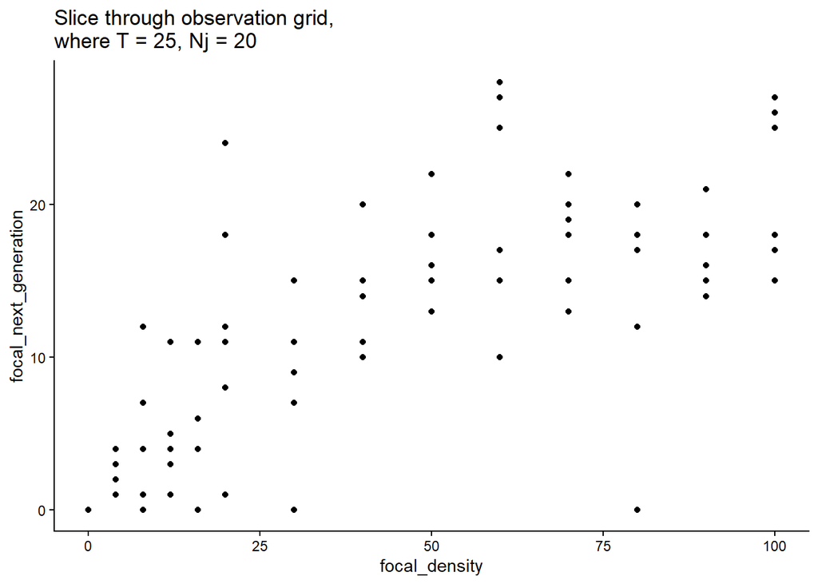

```r
dat %>%
  filter( temp == 25, comp_density == 20) %>%
  ggplot( aes( x = focal_density, y = focal_next_generation))+
  geom_point()+
  theme_classic()+
  ggtitle( label = 'Slice through observation grid,\nwhere T = 25, Nj = 20')
```

## Plotting Response Surfaces

Here plotting out expected value surfaces.

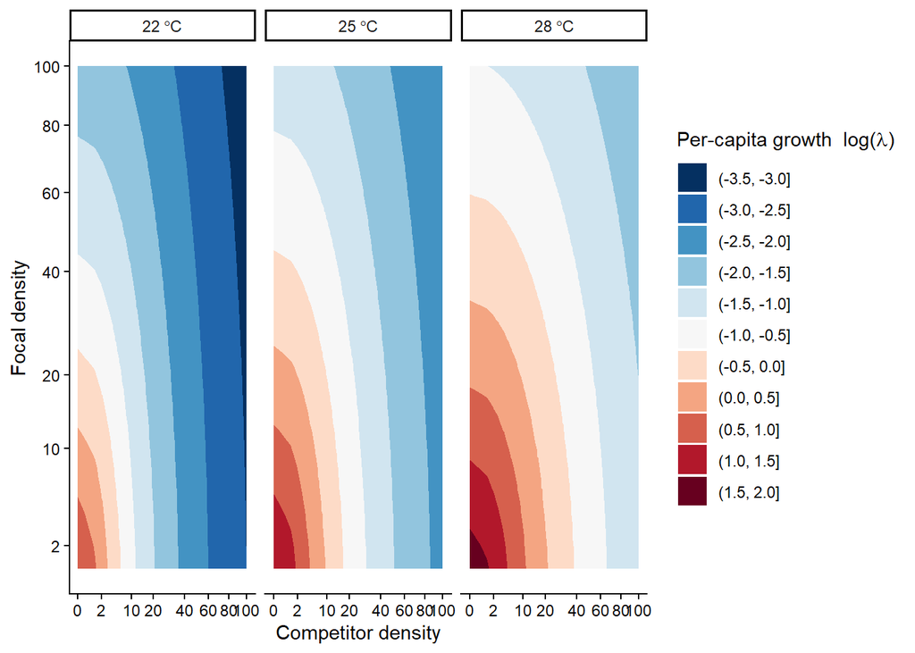

```r
GridPoints<- c(0, 2,10, 20, 40, 60, 80, 100)
breaks_loglambda <- seq(-4, 4, by = 0.5)

expand_grid(temp = c(22, 25, 28),
            focal_density = seq(1, 100, length.out = 100),
            comp_density = seq(0, 100, length.out = 100)) %>%
  mutate( therm_perf = B0 * temp * (temp - Tmin) *sqrt(pmax(Tmax - temp, 0)),
          alphaij =alphaij0 + alphaijT * (temp - 20),
          lambda = therm_perf / (1 + alphaii * focal_density + alphaij * comp_density)) %>%
  mutate( focal_density_plot = sqrt(focal_density),
          comp_density_plot = sqrt(comp_density),
          log_lambda = log(lambda))%>%
  ggplot(  aes(  x = comp_density_plot,
                 y = focal_density_plot,
                 z = log_lambda )) +
  geom_contour_filled( breaks = breaks_loglambda) +
  scale_fill_brewer(palette = "RdBu",
                    direction = -1,
                    name = expression("Per-capita growth  log(" * lambda * ")"))+
  facet_wrap(~ temp, nrow = 1,
             labeller = label_bquote( .(temp) ~ degree*C)) +
  scale_x_continuous( breaks = sqrt(GridPoints),
                      labels = GridPoints ) +
  scale_y_continuous( breaks = sqrt(GridPoints),
                      labels = c(GridPoints)) +
  labs(x = "Competitor density",
       y = "Focal density",
       fill = "log(λ)") +
  theme_classic()
```

# Fitting GAMs with differnt orders of interactions.

Here fitting 3 demonstration models of $N_{i,t+1}$ that include just direct effects of the three predictors (m1), pairwise interactions (m2), and a three-way interaction (m3).

The model includes a log-offset and a negatove-binomial distribution so the model can be directly fit to the observation data, and fit the per-capita population growth surface.

i.e.:

$$\log(E[N_{t+1}])
=
\underbrace{\log(N_t)}_{\text{offset}}
+
\underbrace{f(T,N_t,N_j)}_{\text{GAM learns this}}.$$

and hence:

$$\lambda =
\frac{E[N_{t+1}]}{N_t}
=
\exp[f(T,N_t,N_j)].$$

Note that the underlying model that the data was generated from does not include a direct three-way interaction. So if the model is behaving well, `m3` should not explain more of the variance than `m2`

```r
dat_nb <- filter(dat, focal_density > 0)### Don't fit to clear cases of zero.

m1 <- gam(focal_next_generation ~
            offset(log(focal_density)) +
            s(temp, k = 7) +
            s(focal_density, k = 8) +
            s(comp_density, k = 8),
          family = nb(), method = "REML", data = dat_nb)

m2 <- gam(  focal_next_generation ~
              offset(log(focal_density)) +

              s(temp, k = 7) +
              s(focal_density, k = 8) +
              s(comp_density, k = 8) +
              ## two way interactions:
              ti(temp, focal_density, k = c(6, 6)) +
              ti(temp, comp_density, k = c(6, 6)) +
              ti(focal_density, comp_density, k = c(6, 6)),

            family = nb(), method = "REML", data = dat_nb)

m3 <- gam( focal_next_generation ~
             offset(log(focal_density)) +
             s(temp, k = 7) +
             s(focal_density, k = 8) +
             s(comp_density, k = 8) +
             ti(temp, focal_density, k = c(6, 6)) +
             ti(temp, comp_density, k = c(6, 6)) +
             ti(focal_density, comp_density, k = c(6, 6)) +
             ## three-way interactions
             ti(temp, focal_density, comp_density, k = c(5, 5, 5)),

           family = nb(), method = "REML", data = dat_nb)
```

```r
summary(m1)
```

```
##
## Family: Negative Binomial(3.341)
## Link function: log
##
## Formula:
## focal_next_generation ~ offset(log(focal_density)) + s(temp,
##     k = 7) + s(focal_density, k = 8) + s(comp_density, k = 8)
##
## Parametric coefficients:
##              Estimate Std. Error z value Pr(>|z|)
## (Intercept) -1.296911   0.007351  -176.4   <2e-16 ***
## ---
## Signif. codes:  0 '***' 0.001 '**' 0.01 '*' 0.05 '.' 0.1 ' ' 1
##
## Approximate significance of smooth terms:
##                    edf Ref.df Chi.sq p-value
## s(temp)          4.159  4.943   2692  <2e-16 ***
## s(focal_density) 5.882  6.598   3192  <2e-16 ***
## s(comp_density)  6.310  6.832   8366  <2e-16 ***
## ---
## Signif. codes:  0 '***' 0.001 '**' 0.01 '*' 0.05 '.' 0.1 ' ' 1
##
## R-sq.(adj) =  0.492   Deviance explained = 60.6%
## -REML =  26617  Scale est. = 1         n = 8736
```

```r
summary(m2)
```

```
##
## Family: Negative Binomial(4.094)
## Link function: log
##
## Formula:
## focal_next_generation ~ offset(log(focal_density)) + s(temp,
##     k = 7) + s(focal_density, k = 8) + s(comp_density, k = 8) +
##     ti(temp, focal_density, k = c(6, 6)) + ti(temp, comp_density,
##     k = c(6, 6)) + ti(focal_density, comp_density, k = c(6, 6))
##
## Parametric coefficients:
##             Estimate Std. Error z value Pr(>|z|)
## (Intercept) -1.35279    0.00733  -184.6   <2e-16 ***
## ---
## Signif. codes:  0 '***' 0.001 '**' 0.01 '*' 0.05 '.' 0.1 ' ' 1
##
## Approximate significance of smooth terms:
##                                   edf Ref.df  Chi.sq  p-value
## s(temp)                         4.320  5.096 3039.79  < 2e-16 ***
## s(focal_density)                4.552  5.454 2209.24  < 2e-16 ***
## s(comp_density)                 6.220  6.790 9335.69  < 2e-16 ***
## ti(temp,focal_density)          1.025  1.049   20.54 8.07e-06 ***
## ti(temp,comp_density)           4.782  6.416  158.30  < 2e-16 ***
## ti(focal_density,comp_density) 16.426 19.686  993.22  < 2e-16 ***
## ---
## Signif. codes:  0 '***' 0.001 '**' 0.01 '*' 0.05 '.' 0.1 ' ' 1
##
## R-sq.(adj) =  0.645   Deviance explained =   65%
## -REML =  26115  Scale est. = 1         n = 8736
```

```r
summary(m3)
```

```
##
## Family: Negative Binomial(4.101)
## Link function: log
##
## Formula:
## focal_next_generation ~ offset(log(focal_density)) + s(temp,
##     k = 7) + s(focal_density, k = 8) + s(comp_density, k = 8) +
##     ti(temp, focal_density, k = c(6, 6)) + ti(temp, comp_density,
##     k = c(6, 6)) + ti(focal_density, comp_density, k = c(6, 6)) +
##     ti(temp, focal_density, comp_density, k = c(5, 5, 5))
##
## Parametric coefficients:
##              Estimate Std. Error z value Pr(>|z|)
## (Intercept) -1.354579   0.007384  -183.5   <2e-16 ***
## ---
## Signif. codes:  0 '***' 0.001 '**' 0.01 '*' 0.05 '.' 0.1 ' ' 1
##
## Approximate significance of smooth terms:
##                                        edf Ref.df   Chi.sq  p-value
## s(temp)                              4.319  5.095 2942.663  < 2e-16 ***
## s(focal_density)                     4.534  5.437 2130.370  < 2e-16 ***
## s(comp_density)                      6.219  6.789 9203.049  < 2e-16 ***
## ti(temp,focal_density)               1.011  1.021   23.652 1.95e-06 ***
## ti(temp,comp_density)                4.979  6.760  160.787  < 2e-16 ***
## ti(focal_density,comp_density)      16.496 19.757  986.522  < 2e-16 ***
## ti(temp,focal_density,comp_density)  3.847  5.480    9.021    0.139
## ---
## Signif. codes:  0 '***' 0.001 '**' 0.01 '*' 0.05 '.' 0.1 ' ' 1
##
## R-sq.(adj) =  0.646   Deviance explained = 65.1%
## -REML =  26113  Scale est. = 1         n = 8736
```

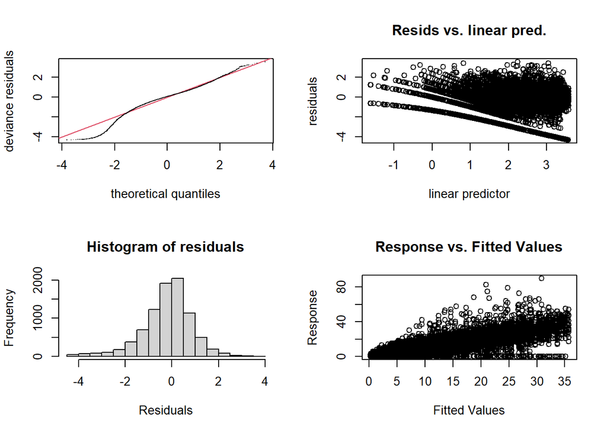

```
##
## Method: REML   Optimizer: outer newton
## full convergence after 7 iterations.
## Gradient range [-0.002778575,0.001247089]
## (score 26113.11 & scale 1).
## Hessian positive definite, eigenvalue range [0.001150434,1574.807].
## Model rank =  160 / 160
##
## Basis dimension (k) checking results. Low p-value (k-index<1) may
## indicate that k is too low, especially if edf is close to k'.
##
##                                        k'   edf k-index p-value
## s(temp)                              6.00  4.32    0.94   0.025 *
## s(focal_density)                     7.00  4.53    0.95   0.160
## s(comp_density)                      7.00  6.22    0.94   0.055 .
## ti(temp,focal_density)              25.00  1.01    0.97   0.565
## ti(temp,comp_density)               25.00  4.98    0.96   0.375
## ti(focal_density,comp_density)      25.00 16.50    0.97   0.630
## ti(temp,focal_density,comp_density) 64.00  3.85    0.96   0.400
## ---
## Signif. codes:  0 '***' 0.001 '**' 0.01 '*' 0.05 '.' 0.1 ' ' 1
```

```r
par(mfrow= c(2,2))
gam.check(m3)
```

### Slice Plots to inspect

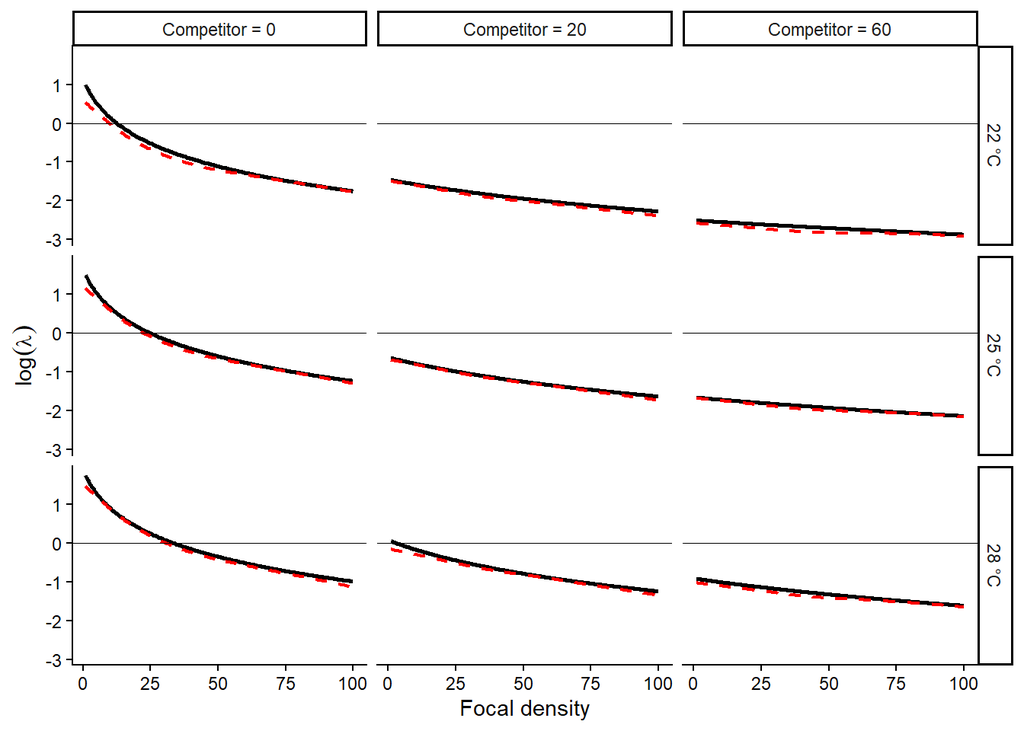

```r
slice_dat <- expand_grid(temp = c(22, 25, 28),
                         comp_density = c(0, 20, 60),
                         focal_density = seq(1, 100, length.out = 200)) %>%
  mutate(therm_perf = B0 * temp * (temp - Tmin) * sqrt(pmax(Tmax - temp, 0)),
         alphaij =alphaij0 + alphaijT * (temp - 20),
         lambda_true = therm_perf / (1 +  alphaii * focal_density +  alphaij * comp_density),
         log_lambda_true = log(lambda_true))

slice_dat$N_next_hat <- predict(m3,newdata = slice_dat,type = "response")
slice_dat$lambda_hat <- slice_dat$N_next_hat / slice_dat$focal_density
slice_dat$log_lambda_hat <-log(slice_dat$lambda_hat)


slice_dat$N_next_hat <- predict(m2, newdata = slice_dat, type = "response")

slice_dat <- slice_dat %>%
  mutate(lambda_hat = N_next_hat / focal_density,
    log_lambda_hat = log(lambda_hat))

ggplot(slice_dat, aes(x = focal_density)) +
  geom_line(aes(y = log_lambda_true),linewidth = 1) +
  geom_line( aes(y = log_lambda_hat), linetype = 2, linewidth = 0.8, col = 'red') +
  facet_grid(temp ~ comp_density,
    labeller = labeller( temp = function(x) paste0(x, " °C"),
      comp_density =function(x) paste0("Competitor = ", x))) +
  geom_hline(yintercept = 0,linewidth = 0.3) +
  labs(x = "Focal density",y = expression(log(lambda)) ) +
  theme_classic()
```

# Testing effect of increasing sample size.

Here varying the number of replicates per level combination, regenerating independent datasets, and then refitting the ‘m2’ (pairwise interactions)

## Function:

```r
fit_one <- function(n_rep, container = c('bottle', 'vial')[1]) {

  ### Generating data
  dat <- expand_grid(temp = seq(22, 28, length.out = 7),
                     focal_density = density_values,
                     comp_density =density_values,
                     replicate = 1:n_rep) %>% # number of replicates per level
    filter(focal_density != 0 )

  ### Underlying biological response surface
  # temp-dependent intrinsic growth
  therm_perf <-B0 * dat$temp * (dat$temp - Tmin) * sqrt(pmax(Tmax - dat$temp, 0))
  alphaij <-alphaij0 + alphaijT * (dat$temp - 20)
  mu <-dat$focal_density *therm_perf/( 1+alphaii*dat$focal_density+alphaij*dat$comp_density)
  # Noise
  shape_bottle <- 4 * exp( shape_intercept + shape_focal * dat$focal_density)
  shape_vial <- 4 * exp( shape_intercept + shape_focal * dat$focal_density)
  structural_zero <- runif(nrow(dat)) < zi  # Structural zero component
  # Generate next-generation population size
  dat$focal_next_generation <- 0
  positive <- (!structural_zero) & (mu > 0)

  if( container == 'bottle'){
    dat$focal_next_generation[positive] <- rnbinom( sum(positive),
                                                    size = shape_bottle[positive],
                                                    mu   = mu[positive])
  }
  if( container == 'vial'){
    dat$focal_next_generation[positive] <- rnbinom( sum(positive),
                                                    size = shape_vial[positive],
                                                    mu   = mu[positive])
  }


  # Pairwise-context GAM
  mod <- gam(focal_next_generation ~
               offset(log(focal_density)) +
               s(temp, k = 7) +
               s(focal_density, k = 8) +
               s(comp_density, k = 8) +
               ti(temp, focal_density, k = c(6, 6)) +
               ti(temp, comp_density,  k = c(6, 6)) +
               ti(focal_density, comp_density, k = c(6, 6)),
             family = nb(),
             method = "REML",data = dat)

  # Extract smooth-term table
  sm <- summary(mod)$s.table

  tibble(n_rep = n_rep,
         total_n = nrow(dat),
         p_temp_comp = sm["ti(temp,comp_density)", "p-value"],
         p_temp_focal =  sm["ti(temp,focal_density)", "p-value"],
         p_focal_comp = sm["ti(focal_density,comp_density)", "p-value"],
         detected =p_temp_comp < 0.05,
         deviance_explained =summary(mod)$dev.expl
  )
}


fit_one_safe <- safely(fit_one)
```

## Fitting 10 times:

```r
set.seed(123)
n_reps <- c(1)
n_sims <- 10

results <- map_dfr(rep(n_reps,each =n_sims),
                   fit_one_safe )
```

# Testing recovery of a three-way interaction

What if a there was a three-way interaction between temperature and two species density? How many observations would be needed to reliably pull this out? This wasn’t directly tested for in the original modelling, but can be added into the simulator.

The three way interaction here is: “The per-capita competitive effect of species $j$ can differ by up to ±20% according to the joint temperature and focal-density context.” For this reason, it is fit using scaled temperature and focal density.

```r
# Values to centre contextual variables
T_centre <- 25
T_scale <- 3
N_centre <- mean(density_values)
N_scale <- max(abs(density_values - N_centre))

fit_model_3way <- function(n_rep, beta3, container = c('bottle', 'vial')[1]) {
  ## Output progress
  print(n_rep )
  print(Sys.time())

  ### Generating data
  dat <- expand_grid(temp = seq(22, 28, length.out = 7),
                     focal_density = density_values,
                     comp_density =density_values,
                     replicate = 1:n_rep) %>% # number of replicates per level
    filter(focal_density != 0 )

  ### Underlying biological response surface
  # temp-dependent intrinsic growth
  therm_perf <-B0 * dat$temp * (dat$temp - Tmin) *sqrt(pmax(Tmax - dat$temp, 0))
  # Existing temperature-dependent competition
  alphaij_base <- alphaij0 +  alphaijT * (dat$temp - 20)

   # Standardised contextual variables
  T_scaled <-  (dat$temp - T_centre) / T_scale
  N_scaled <- (dat$focal_density - N_centre) / N_scale

  #####################################
  # Three-way modification
  threeway_multiplier <- 1 + beta3 * T_scaled * N_scaled
  alphaij <- alphaij_base * threeway_multiplier
  ####################################

  # Population growth
  mu <- dat$focal_density *  therm_perf /(1 +alphaii * dat$focal_density + alphaij * dat$comp_density)

  # Noise
  shape_bottle <- 4 * exp( shape_intercept + shape_focal * dat$focal_density)
  shape_vial <- 4 * exp( shape_intercept + shape_focal * dat$focal_density)
  structural_zero <- runif(nrow(dat)) < zi  # Structural zero component
  # Generate next-generation population size
  dat$focal_next_generation <- 0
  positive <- (!structural_zero) & (mu > 0)

  if( container == 'bottle'){
    dat$focal_next_generation[positive] <- rnbinom( sum(positive),
                                                    size = shape_bottle[positive],
                                                    mu   = mu[positive])
  }
  if( container == 'vial'){
    dat$focal_next_generation[positive] <- rnbinom( sum(positive),
                                                    size = shape_vial[positive],
                                                    mu   = mu[positive])
  }


  # Pairwise-context GAM
  mod <- gam(focal_next_generation ~
               offset(log(focal_density)) +
               s(temp, k = 7) +
               s(focal_density, k = 8) +
               s(comp_density, k = 8) +
               ti(temp, focal_density, k = c(6, 6)) +
               ti(temp, comp_density,  k = c(6, 6)) +
               ti(focal_density, comp_density, k = c(6, 6)) +
               ti(temp, focal_density, comp_density,
                  k = c(5, 5, 5)),
             family = nb(),
             method = "REML",data = dat)

  # Extract smooth-term table
  sm <- summary(mod)$s.table

  tibble(n_rep = n_rep,
         total_n = nrow(dat),
         beta3= beta3,
         p_temp_comp = sm["ti(temp,comp_density)", "p-value"],
         p_temp_focal =  sm["ti(temp,focal_density)", "p-value"],
         p_focal_comp = sm["ti(focal_density,comp_density)", "p-value"],
         p_3way = sm["ti(temp,focal_density,comp_density)", "p-value"],
         detected =p_3way < 0.05,
         deviance_explained =summary(mod)$dev.expl
  )
}
```

## Runnning detection of 3-way interactions

```r
### Null Test Without HOIs
null_test <- map_dfr(1:30,~ fit_model_3way( n_rep = 4,beta3 = 0))

write_csv(null_test, 'null_test.csv' )

n_reps <- c(1,2,4,8)
n_sims <- 20


### Test *With* HOIs at 20% effect
results_beta3_0.2 <- map_dfr(rep(n_reps,each =n_sims),
                             fit_model_3way , beta3 = 0.2)

write_csv(results_beta3_0.2, 'results_beta3_0.2.csv' )
```

```r
null_test<- read_csv('null_test.csv' )
results_beta3_0.2<- read_csv('results_beta3_0.2.csv' )
mean(null_test$detected)
```

```
## [1] 0.1
```

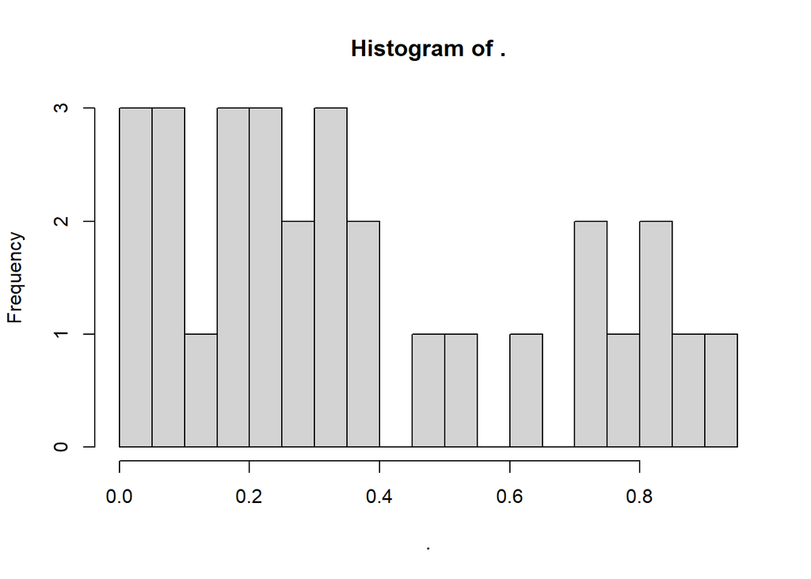

```r
null_test$p_3way %>% hist(breaks = 20)
```

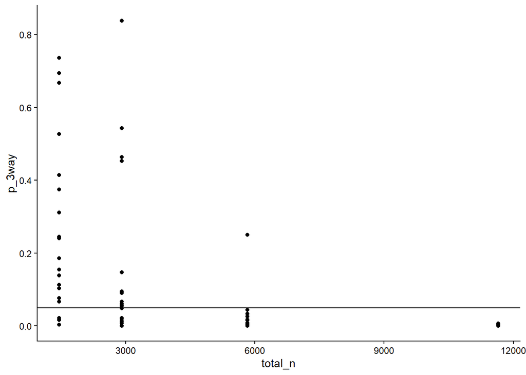

```r
results_beta3_0.2 %>%
  ggplot(aes( x=total_n , y =p_3way  ))+
  geom_point()+
  geom_hline( yintercept = 0.05)+
  theme_classic()
```

```r
results_beta3_0.2 %>%
  count( total_n, detected)
```

```
## # A tibble: 7 × 3
##   total_n detected     n
##     <dbl> <lgl>    <int>
## 1    1456 FALSE       16
## 2    1456 TRUE         4
## 3    2912 FALSE       11
## 4    2912 TRUE         9
## 5    5824 FALSE        1
## 6    5824 TRUE        19
## 7   11648 TRUE        20
```

# Repeating without vial-to-bottle scaling

## Visualisation of noise

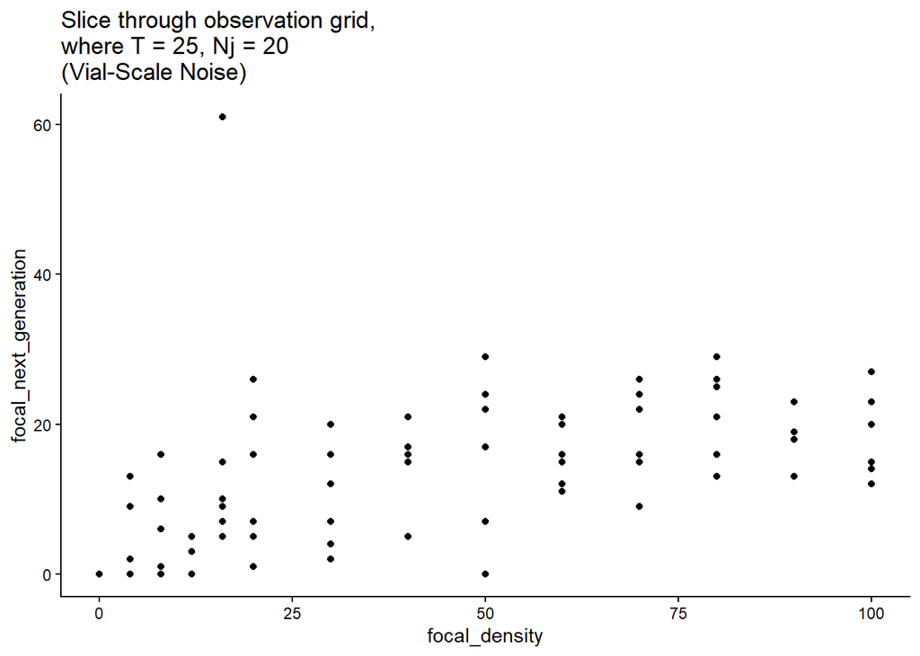

```r
dat_vial <- dat

# Structural zero component
structural_zero <- runif(nrow(dat_vial)) < zi

# Generate next-generation population size
dat_vial$focal_next_generation <- 0
positive <- (!structural_zero) & (mu > 0)

set.seed(1)
dat_vial$focal_next_generation[positive] <-rnbinom( sum(positive),
                                               size = shape_vials[positive],
                                               mu   = mu[positive])

dat_vial %>%
  filter( temp == 25, comp_density == 20) %>%
  ggplot( aes( x = focal_density, y = focal_next_generation))+
  geom_point()+
  theme_classic()+
  ggtitle( label = 'Slice through observation grid,\nwhere T = 25, Nj = 20\n(Vial-Scale Noise)')
```

# Testing effect of increasing sample size on recovery of a three-way interaction

## Runnning detection of 3-way interactions

```r
null_test <- map_dfr(1:30,~ fit_model_3way( n_rep = 4,beta3 = 0, container = 'vial'))

write_csv(null_test, 'null_test_noScaling.csv' )

n_reps <- c(1,2,4,8)
n_sims <- 20

results_beta3_0.2 <- map_dfr(rep(n_reps,each =n_sims),
                             fit_model_3way , beta3 = 0.2, container = 'vial')

write_csv(results_beta3_0.2, 'results_beta3_0.2_noScaling.csv' )
```

```r
null_test<- read_csv('null_test_noScaling.csv' )
results_beta3_0.2<- read_csv('results_beta3_0.2_noScaling.csv' )
mean(null_test$detected)
```

```
## [1] 0.1333333
```

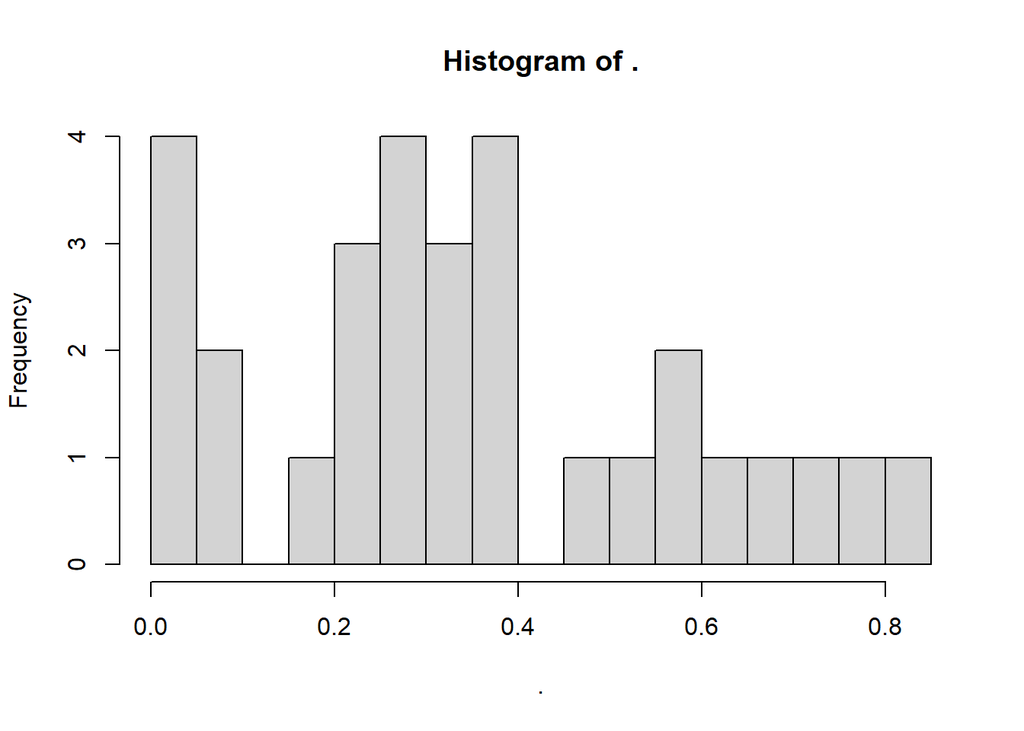

```r
null_test$p_3way %>% hist(breaks = 20)
```

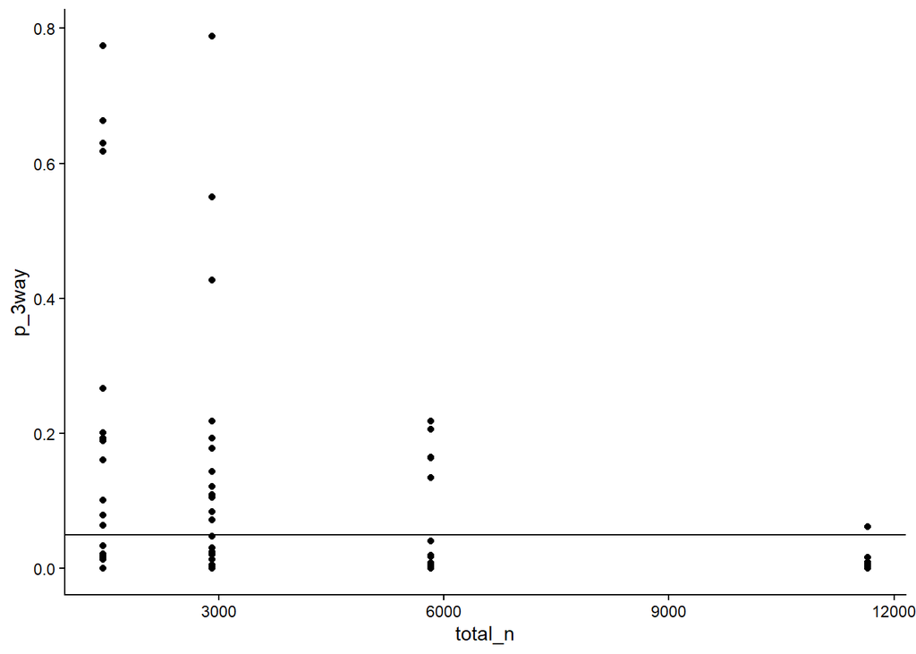

```r
results_beta3_0.2 %>%
  ggplot(aes( x=total_n , y =p_3way  ))+
  geom_point()+
  geom_hline( yintercept = 0.05)+
  theme_classic()
```

```r
results_beta3_0.2 %>%
  count( total_n, detected)
```

```
## # A tibble: 8 × 3
##   total_n detected     n
##     <dbl> <lgl>    <int>
## 1    1456 FALSE       13
## 2    1456 TRUE         7
## 3    2912 FALSE       12
## 4    2912 TRUE         8
## 5    5824 FALSE        5
## 6    5824 TRUE        15
## 7   11648 FALSE        1
## 8   11648 TRUE        19
```